# Chapter 4 - Data Visualization

Edson Raul Cepeda Marquez

### Basic graphics

The basic plotting system is implemented in the `graphics` package. >

```r
#library(help = "graphics")
library("magrittr")
```

The main plotting function is `plot()`

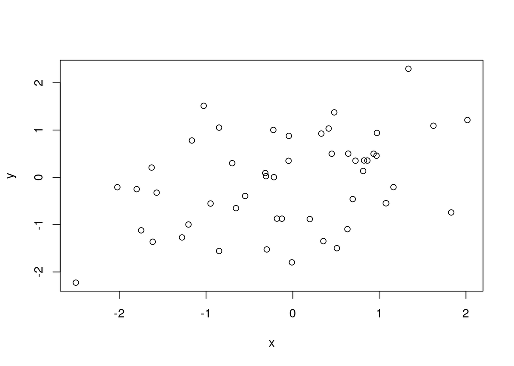

```r
x <- rnorm(50)
y <- rnorm(50)
plot(x,y)
```

The `plot()` function takes a data argument you can uso to plot data from a data frame.

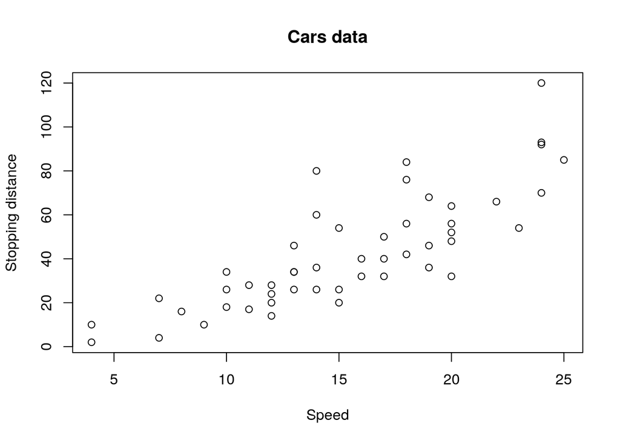

```r
data(cars)
# Wrong: cars %>% plot(speed,dist,data = .)
cars %$% plot(speed, dist, main = "Cars data",
              xlab = "Speed", ylab = "Stopping distance")
```

The data argument `plot()` is used when the variables of the plot are specified as a formula. It is combined with a formula that the data parameter of the `plot()` function is used. if the $x$ and $y$ values are specified in a formula, you can give the function a data frame that holds the variables and plot from that, as follows:

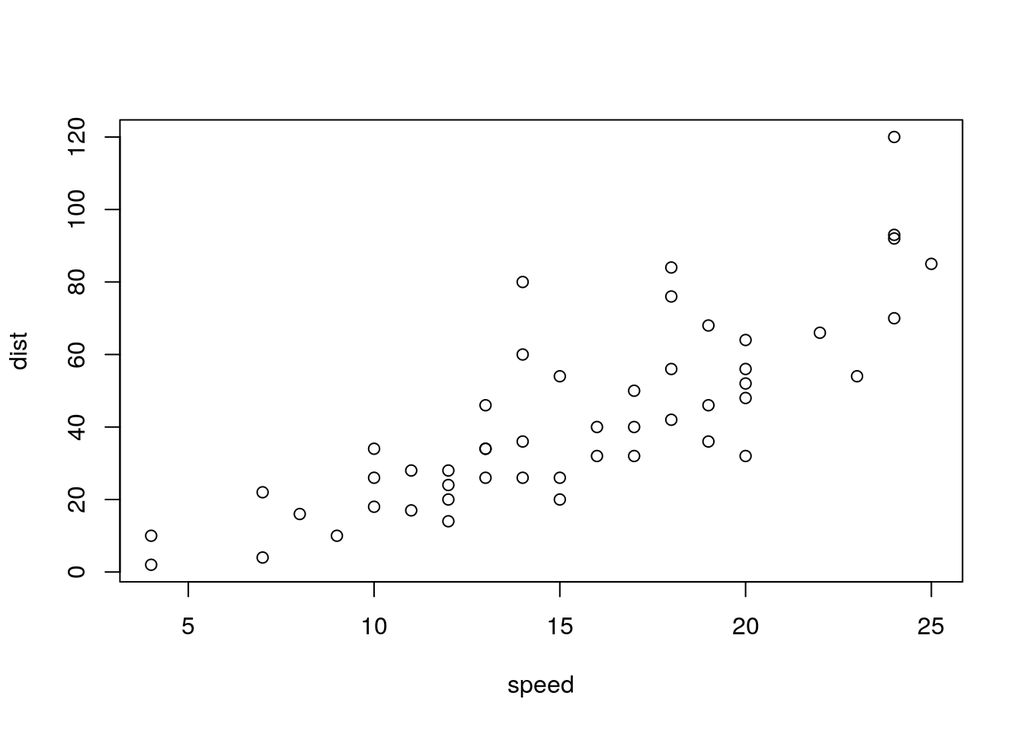

```r
cars %>% plot(dist ~ speed, data = .)
```

by default it shows the dat as points, but you can specify a `type` paremeter to display the data in other ways.

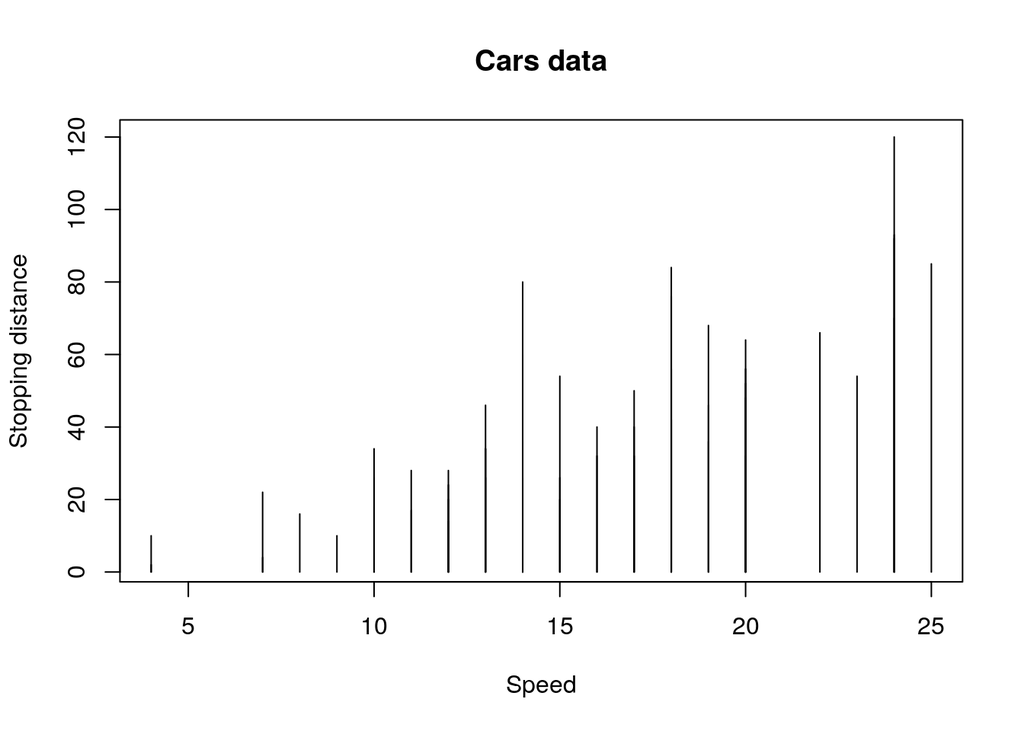

```r
cars %$% plot(speed, dist, main = "Cars data", type = "h",
              xlab = "Speed", ylab = "Stopping distance")
```

To get a histogram of a single variable, use the function `hist()` instead of `plot()`.

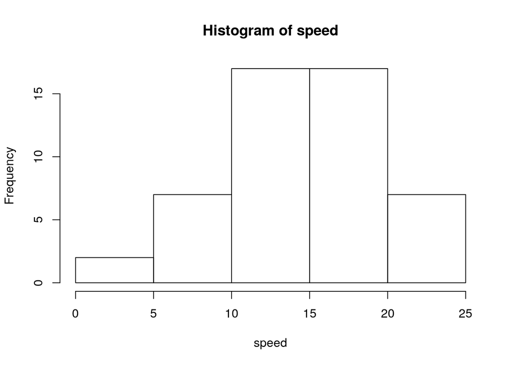

```r
cars %$% hist(speed)
```

`plot()` is a *generic* functio it means that it will have different functionality depending on the parameters you give it. For example, created with the `lm()` function, has its own plotting routine.

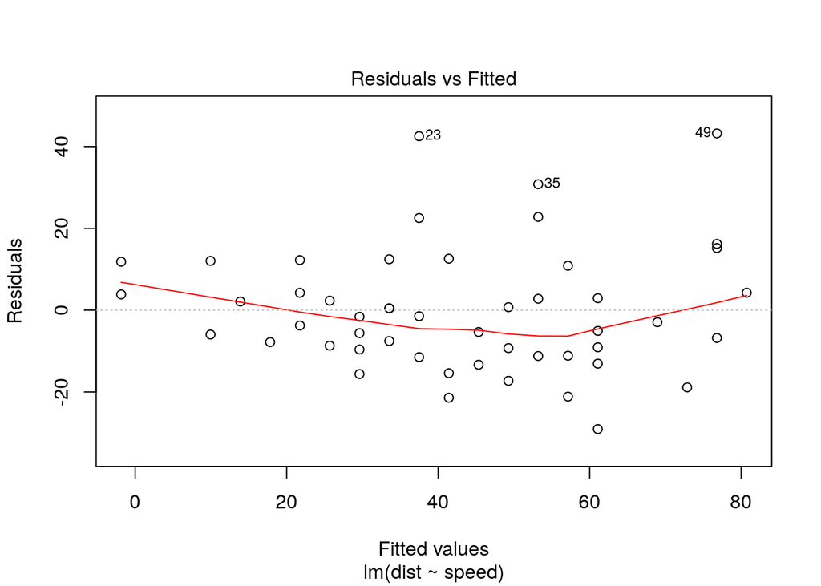

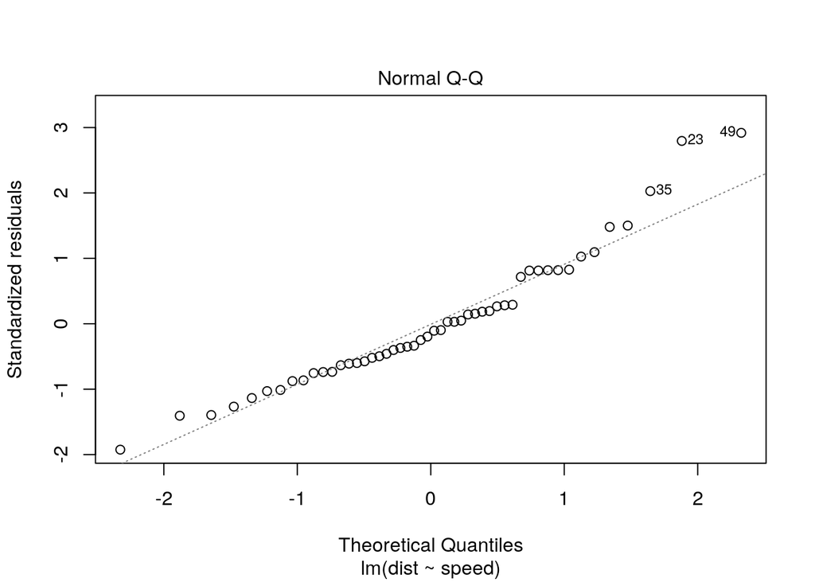

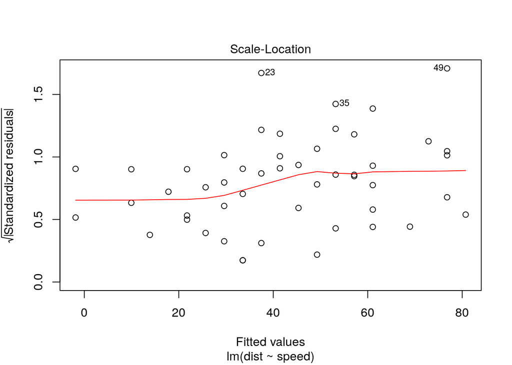

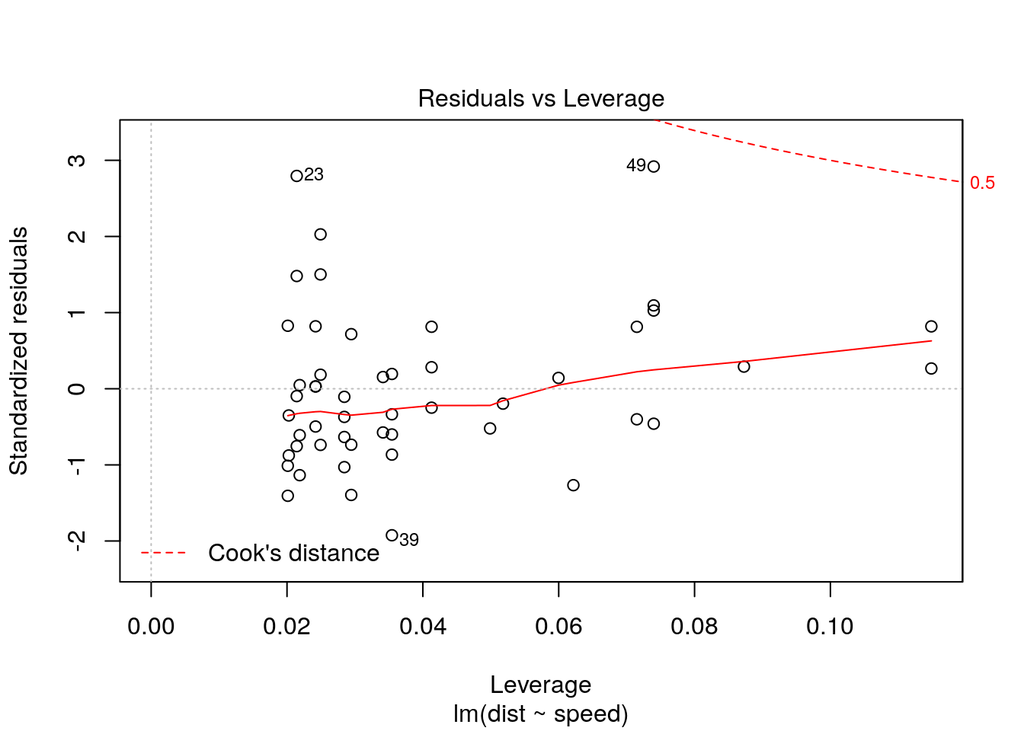

```r
cars %>% lm(dist ~ speed, data = .) %>% plot
```

It will five you several summary plots for visualizing the quality of the linear fit. **Many model-fitting algorithms return a fitted object that has specialized plotting functionality**.

`lines()` and `points()` functions.

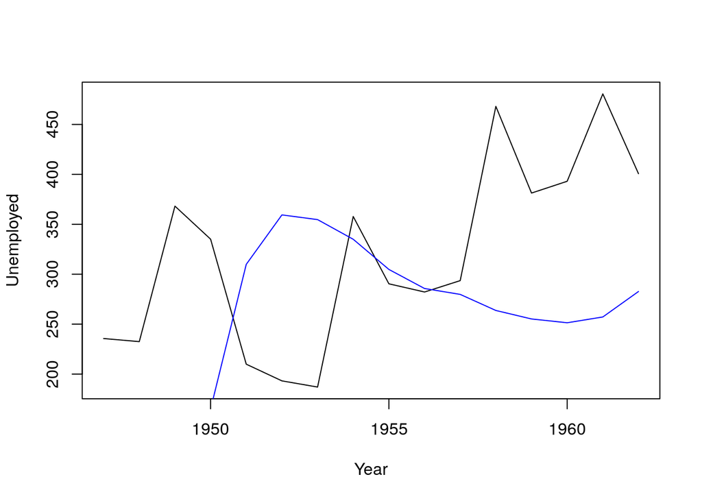

```r
data(longley)
longley %>% plot(Unemployed ~ Year, data = ., type = "l")
longley %>% lines(Armed.Forces ~ Year, data = ., col = "blue")
```

Plot function sets y-axis range by itself. To manually set the limits of y-axis, `ylim` parameter must be used.

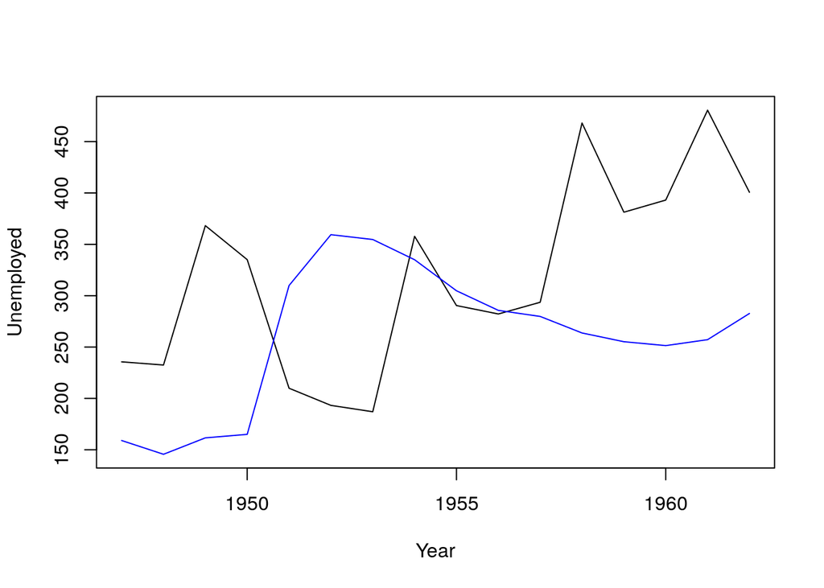

```r
longley %$% plot(Unemployed ~ Year, type = "l",
                 ylim = range(c(Unemployed, Armed.Forces)))
longley %>% lines(Armed.Forces ~ Year, data = ., col = "blue")
```

Like `plot()`, the other plotting funcyions are usually generic. This means you can sometimes give them objects such as fitted models. The `abline()` function is one such case. It plots lines of the form $y = a + bx$, but there is a variant of it that takes a linear model as input and plot the best fitting line defined by the model. So you can plot the cars data together with the best-fitted line using the combination of the `lm()` and `abline()` functions.

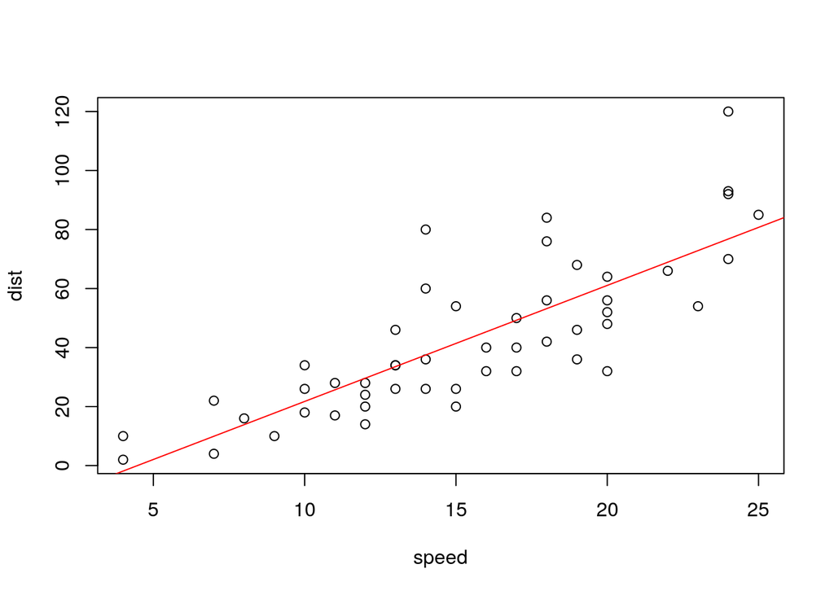

```r
cars %>% plot(dist ~ speed, data = .)
cars %>% lm(dist ~ speed, data = .) %>% abline(col = "red")
```

Plotting usually follows this patter. First. There is a call to `plot()` that sets up the canvas to plot on, possibly adjusting the axes. Then. Any additional data points are plotted. Finally. There might be some annotation like adding text labels or margin notes. (see the `t$ext()` and `mtext()` functions).

If you want to select the shape of points or their color according to the other data features, e.g., plotting yo *iris* data with data points in different shapes according to the *Species* variable, you need to map features to columns.

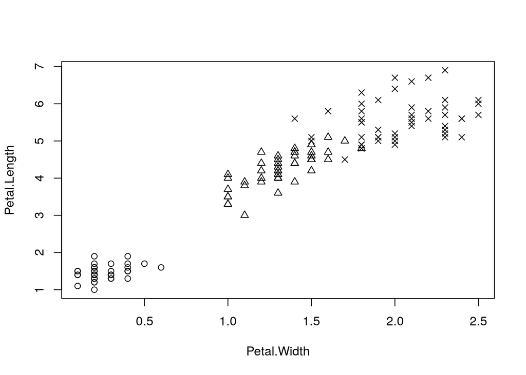

```r
shape_map <- c("setosa" = 1,
               "versicolor" = 2,
               "virginica" = 4)
iris %$% plot(Petal.Length ~ Petal.Width, pch = shape_map[Species])
```